# Bellabeat Fitness Tracker Case Study Using R

Ysobel Gallo

2023-12-27

## Background Scenario

Bellabeat is a tech-driven women’s wellness company. It’s main product is the “Leaf” a wearable wellness tracker measuring data on sleep, activity, stress, and menstrual cycle that syncs with the Bellabeat app on your phone, allowing you to track your own wellness data in real time. Bellabeat’s main marketing slant is to empower their users to make healthy decisions based on their own unique lives.

## Business Objective

Analyze trends in consumer use of other, existing health trackers and apply it to optimize Bellabeat’s market relevance.

## Preparing the Data

Data for this project included 33 FitBit participants. Data was gathered by Mobius, and is available open source through Kaggle.

Data contains 18 tables with both daily and hourly activity data and heart-rate every five seconds. My goal is to look for overall trends, so I will focus on the daily data, as well as the hourly_intensities to get an idea of when people prefer to workout.

I have already loaded the files into Google sheets and used that to get a feel for the contents as well as to trim white space, remove duplicates, convert columns, etc. I’ll load the cleaned data into R along with the tidyverse package.

## Analysis Process

We’ll start with the sleep data. First we’ll take a look:

```r
head(sleep)
```

```
## # A tibble: 6 × 9
##           Id SleepDay  Time   `Am/PM` TotalSleepRecords TotalMinutesAsleep
##        <dbl> <chr>     <time> <chr>               <dbl>              <dbl>
## 1 1503960366 4/12/2016 12:00  AM                      1                327
## 2 1503960366 4/13/2016 12:00  AM                      2                384
## 3 1503960366 4/15/2016 12:00  AM                      1                412
## 4 1503960366 4/16/2016 12:00  AM                      2                340
## 5 1503960366 4/17/2016 12:00  AM                      1                700
## 6 1503960366 4/19/2016 12:00  AM                      1                304
## # ℹ 3 more variables: Total_Hours_Asleep <dbl>, TotalTimeInBed <dbl>,
## #   Total_Hours_In_Bed <dbl>
```

```r
sleep %>%
  summarize(Avg_Hours_Asleep=mean(Total_Hours_Asleep)) %>%
  head()
```

```
## # A tibble: 1 × 1
##   Avg_Hours_Asleep
##              <dbl>
## 1             7.00
```

In the head below, we see the data contains both time asleep and time in bed. It might be interesting to see if there is a disparity between the two. We want to know how many hours our users sleep per night, but also how long it takes them to *get to sleep*.

```r
sleep <- sleep %>%
  mutate(Difference = TotalTimeInBed - TotalMinutesAsleep,na.rm=TRUE)

sleep_2 <- sleep %>%
  group_by(Id) %>%
  summarize(Avg_Hours_In_Bed=mean(Total_Hours_In_Bed),
            Avg_Hours_Asleep=mean(Total_Hours_Asleep),
            Avg_Minute_Difference=mean(Difference))

p <- ggplot(data=sleep_2)+
  geom_col(mapping=aes(x=Id,y=Avg_Hours_In_Bed),
           linewidth=2,color="blue")+
  coord_flip()

sleep_figure <- p+
  geom_col(mapping=aes(x=Id,y=Avg_Hours_Asleep),linewidth=1,color="green")+
  coord_flip()+
  labs(title="Avg Hours in Bed vs Hours Asleep",
       x=" ",
       y="Hours")+
  annotate("text",x=5800000000,y=12,label="46% take >30min
           to fall asleep")+
  theme_bw()
```

[output not shown]

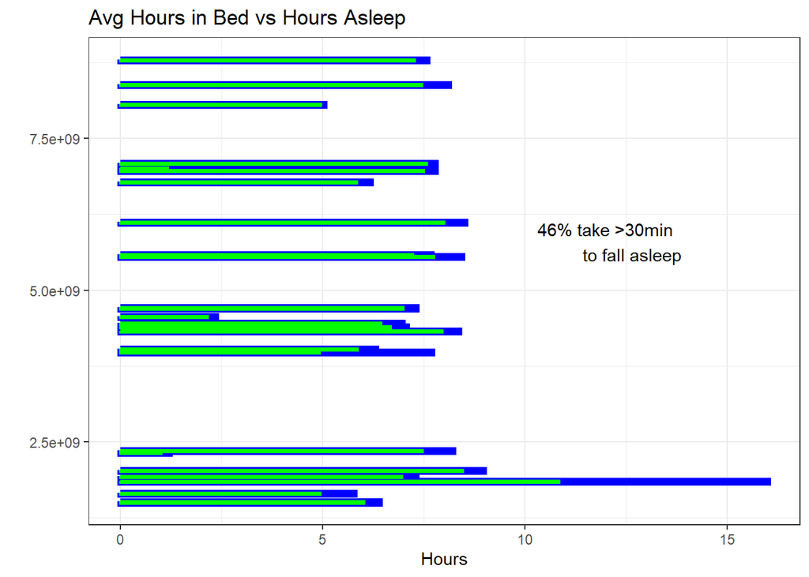

```r
sleep_figure
```

```r
sleep %>%
  summarize(mean(Total_Hours_Asleep))
```

```
## # A tibble: 1 × 1
##   `mean(Total_Hours_Asleep)`
##                        <dbl>
## 1                       7.00
```

```r
sleep_2 %>%
  summarize(Avg_Time_til_Sleep=mean(Avg_Minute_Difference))
```

```
## # A tibble: 1 × 1
##   Avg_Time_til_Sleep
##                <dbl>
## 1               42.5
```

```r
sleep_2 %>%
  select(Avg_Minute_Difference) %>%
  summarize(min_Time_til_Sleep=min(Avg_Minute_Difference),
            max_Time_til_Sleep=max(Avg_Minute_Difference),
            avg_Time_til_Sleep=mean(Avg_Minute_Difference)) %>%
  glimpse()
```

```
## Rows: 1
## Columns: 3
## $ min_Time_til_Sleep <dbl> 3
## $ max_Time_til_Sleep <dbl> 309
## $ avg_Time_til_Sleep <dbl> 42.4783
```

```r
sleep_2 %>%
  count(Avg_Minute_Difference>"30")
```

```
## # A tibble: 2 × 2
##   `Avg_Minute_Difference > "30"`     n
##   <lgl>                          <int>
## 1 FALSE                             13
## 2 TRUE                              11
```

Now it’s time to turn to activity. We’ll start with the steps day as an overall metric of general health. We’ll take a look, clean as needed, and run a summary:

```r
colnames(steps)
```

```
## [1] "Id"          "ActivityDay" "StepTotal"
```

```r
as_tibble(duplicated(steps))
```

```
## # A tibble: 940 × 1
##    value
##    <lgl>
##  1 FALSE
##  2 FALSE
##  3 FALSE
##  4 FALSE
##  5 FALSE
##  6 FALSE
##  7 FALSE
##  8 FALSE
##  9 FALSE
## 10 FALSE
## # ℹ 930 more rows
```

```r
glimpse(steps)
```

```
## Rows: 940
## Columns: 3
## $ Id          <dbl> 1503960366, 1503960366, 1503960366, 1503960366, 1503960366…
## $ ActivityDay <chr> "4/12/2016", "4/13/2016", "4/14/2016", "4/15/2016", "4/16/…
## $ StepTotal   <dbl> 13162, 10735, 10460, 9762, 12669, 9705, 13019, 15506, 1054…
```

```r
steps %>%
  mutate(activity_day=mdy(ActivityDay)) %>%
  glimpse()
```

```
## Rows: 940
## Columns: 4
## $ Id           <dbl> 1503960366, 1503960366, 1503960366, 1503960366, 150396036…
## $ ActivityDay  <chr> "4/12/2016", "4/13/2016", "4/14/2016", "4/15/2016", "4/16…
## $ StepTotal    <dbl> 13162, 10735, 10460, 9762, 12669, 9705, 13019, 15506, 105…
## $ activity_day <date> 2016-04-12, 2016-04-13, 2016-04-14, 2016-04-15, 2016-04-…
```

```r
steps_distinct <- steps %>%
  group_by(Id) %>%
  summarize(average_steps=mean(StepTotal),na.rm=TRUE)
head(steps_distinct)
```

```
## # A tibble: 6 × 3
##           Id average_steps na.rm
##        <dbl>         <dbl> <lgl>
## 1 1503960366        12117. TRUE
## 2 1624580081         5744. TRUE
## 3 1644430081         7283. TRUE
## 4 1844505072         2580. TRUE
## 5 1927972279          916. TRUE
## 6 2022484408        11371. TRUE
```

Our new steps_distinct table shows the average number of steps per day for each individual Id. Now we can use this data to get a summary of our population in general:

```r
steps_distinct %>%
  summarize(min_steps=min(average_steps),max_steps=max(average_steps),average_steps=mean(average_steps))
```

```
## # A tibble: 1 × 3
##   min_steps max_steps average_steps
##       <dbl>     <dbl>         <dbl>
## 1      916.    16040.         7519.
```

Our users range from 900 to 16,000 steps a day, which means we have a diverse group of people. CDC recommends 10,000 steps per day, while a 2020 NIH study found that even just 8,000 steps per day reduced the risk of death within the next 4 years by 51%. [link](https://www.nih.gov/news-events/nih-research-matters/number-steps-day-more-important-step-intensity) Our users are below both of these benchmarks.

Let’s use the activity table to get a closer look.

```r
activity <- activity %>%
  mutate(activity_date=mdy(ActivityDate))

activity %>%
  summarize(avg_fairly_active=mean(FairlyActiveMinutes),
            avg_lightly_active=mean(LightlyActiveMinutes),
            avg_sedentary=mean(SedentaryMinutes),
            avg_very_active=mean(VeryActiveMinutes)) %>%
  head()
```

```
## # A tibble: 1 × 4
##   avg_fairly_active avg_lightly_active avg_sedentary avg_very_active
##               <dbl>              <dbl>         <dbl>           <dbl>
## 1              13.6               193.          991.            21.2
```

```r
activity %>%
  summarize(min_very_active=min(VeryActiveMinutes),
            max_very_active=max(VeryActiveMinutes),
            avg_very_active=mean(VeryActiveMinutes)) %>%
  head()
```

```
## # A tibble: 1 × 3
##   min_very_active max_very_active avg_very_active
##             <dbl>           <dbl>           <dbl>
## 1               0             210            21.2
```

WOW, that is a huge range! Something else is going on here. We need to zoom in on this data more to get a better idea of overall trends. We can see this more clearly by grouping by Id, and turning the totals into a visualization:

```r
activity_distinct <- activity %>%
  group_by(Id)

activity_graphic <- activity_distinct %>%
  summarize(TotalVeryActive=sum(VeryActiveMinutes),
            TotalFairlyActive=sum(FairlyActiveMinutes),
            TotalLightlyActive=sum(LightlyActiveMinutes),
            TotalSedentary=sum(SedentaryMinutes))
head(activity_graphic)
```

```
## # A tibble: 6 × 5
##           Id TotalVeryActive TotalFairlyActive TotalLightlyActive TotalSedentary
##        <dbl>           <dbl>             <dbl>              <dbl>          <dbl>
## 1 1503960366            1200               594               6818          26293
## 2 1624580081             269               180               4758          38990
## 3 1644430081             287               641               5354          34856
## 4 1844505072               4                40               3579          37405
## 5 1927972279              41                24               1196          40840
## 6 2022484408            1125               600               7981          34490
```

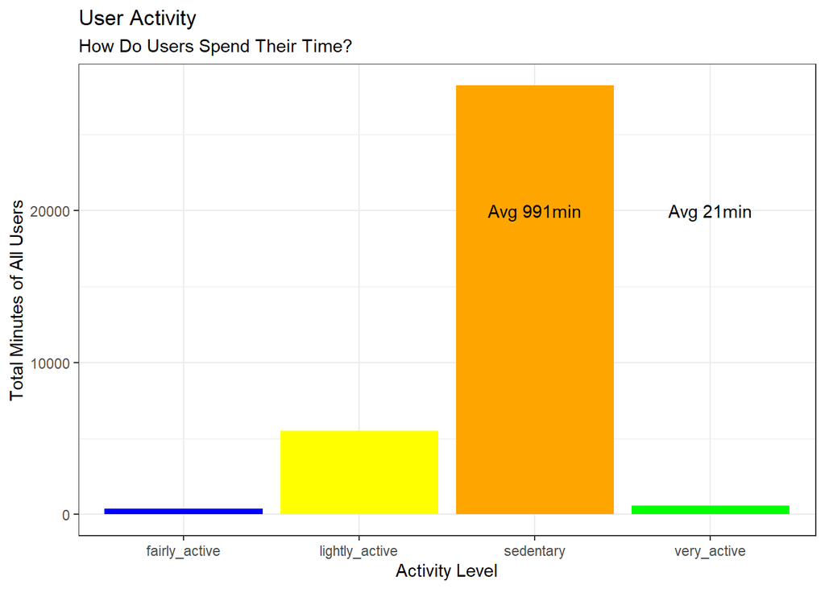

```r
a_graphic_2 <- activity_graphic %>%
  summarize(very_active=mean(TotalVeryActive),
            fairly_active=mean(TotalFairlyActive),
            lightly_active=mean(TotalLightlyActive),
            sedentary=mean(TotalSedentary))

ggplot(data = a_graphic_2 %>% gather(),
       aes(x = key, y = value,)) +
  geom_bar(stat = 'identity',
           fill=c("green","blue","yellow","orange"))+
  labs(title="User Activity",
       subtitle="How Do Users Spend Their Time?",
       x="Activity Level",
       y="Total Minutes of All Users")+
  theme_bw()+
  annotate("text",x=4,y=20000,label="Avg 21min")+
  annotate("text",x=3,y=20000,label="Avg 991min")
```

At first glance, it looks like our users are barely exercising at all. But remember there was a huge range between the min and max values of Very Active Minutes, as well as min and max for step count as well. I wanted to understand why this was happening, so I turned to the hourly data. For this next chunk I used the hourly_intensities table to illustrate what time of day people are more or less active.

```r
hourly_intensities %>%
  mutate(hour_of_day = hour(activity_time)) %>%
  group_by(hour_of_day) %>%
  summarize(total_intensity = sum(total_intensity, na.rm = TRUE)) %>%
  arrange(desc(total_intensity)) %>%
  head(4)
```

```
## # A tibble: 4 × 2
##   hour_of_day total_intensity
##         <int>           <dbl>
## 1          18           19861
## 2          17           19620
## 3          19           19375
## 4          12           18299
```

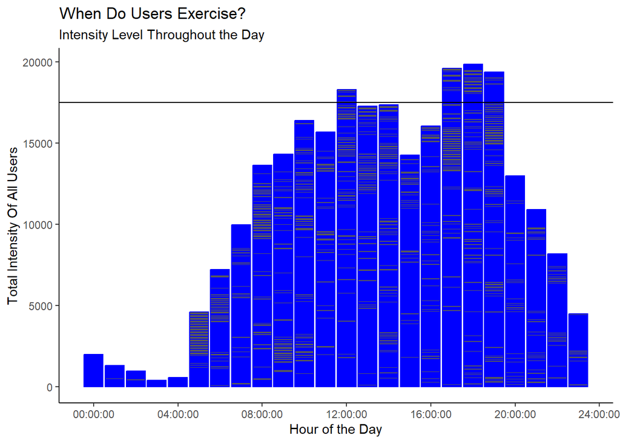

```r
ggplot(data=hourly_intensities)+
  geom_col(mapping=aes(x=activity_time,y=total_intensity),
           color="blue")+
  geom_hline(yintercept=17500,linetype="solid",color="black")+
  labs(title="When Do Users Exercise?",
       subtitle="Intensity Level Throughout the Day",
       x="Hour of the Day",
       y="Total Intensity Of All Users")+
  theme_classic()
```

As we can see, most of our users exercise between 5 and 8 pm, with another uptick around 12-1pm. This leads me to conclude that our users are most likely working full time, and exercising right after work our on their lunch break. This could account for the widely differing values in VeryActiveMinutes, depending on whether an individual user was able to stop by the gym on the way or home that day or not.

## In Summary:

We can put all our data together in a summary table:

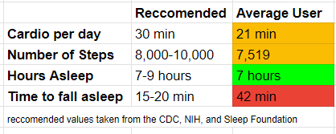

```r
knitr::include_graphics("user_health_summary.png")
```

In conclusion the Fitness tracker users are overall unhealthy, busy people working full time jobs who nevertheless make an effort to exercise regularly.

*The marketing strategy should emphasize how Bellabeat makes wellness low stress, and possible for people with busy schedules.*

## Reccomendations

### Option 1: Short Term

#### *Send activity break or exercise reminders through the app at 12pm and also 5pm*

```
these are peak windows for our users.
```

#### *Include on the app 30 minute workout templates*

```
users currently average 21 minutes, so this both doable and also challenging.
```

#### *Include on the app 1 hour recordings of white noise / sleep sounds*

```
our users have trouble falling asleep
```

### Option 2: Longterm

#### *Gather BMI data for possible focus on weight loss*

```
most of our users are sedentary, without reaching even conservative activity benchmarks for proper health. Based on this, I thought it would be interesting to see the metabolic / weight data.
```

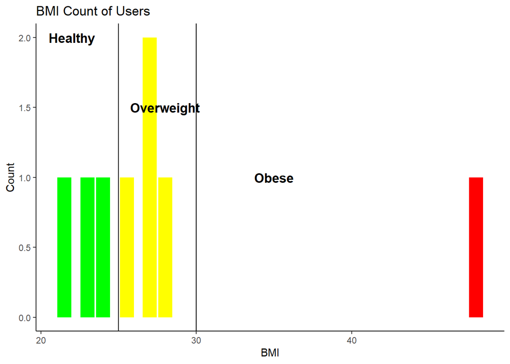

Within this subset over half belong to an unhealthy weight category. Unfortunately, the sample size was too small to use in the main analysis (only 8 participants). More data is needed. If greater research demonstrates a majority of users being overweight, it might be worth targeting our marketing specifically to weight loss.

We already know our users are motivated individuals: after all they regularly exercise after a long day at work, and manage to prioritize a regular 7 hours of sleep. They clearly care about their health. Bellabeat could capitalize on that by offering a tailored exercise templates based on their BMI tier (for focus on either losing weight, or maintaining health) and activity level (to determine what level of difficulty they are willing to do).

In order to do this, however, more BMI data will have to be gathered.